# Questions 1-5

Perez Tellez Cesar Alexander

19/11/2018

> Libraries 1. tydiverse 2. ggplot2 3. forcats 4. dplyr

```r
library(tidyverse)
```

```r
library(ggplot2)
library(forcats)
library(gapminder)
library(dplyr)
```

```r
survey <- read.csv("C:/Users/G50/Documents/R pRogRams/Survey.csv")
```

## Question 1

> Do you contribute to open source projects?

```r
  Q1 <- survey %>% count(OpenSource)
  Q1
```

```
## # A tibble: 2 x 2
##   OpenSource     n
##   <fct>      <int>
## 1 No         55769
## 2 Yes        43086
```

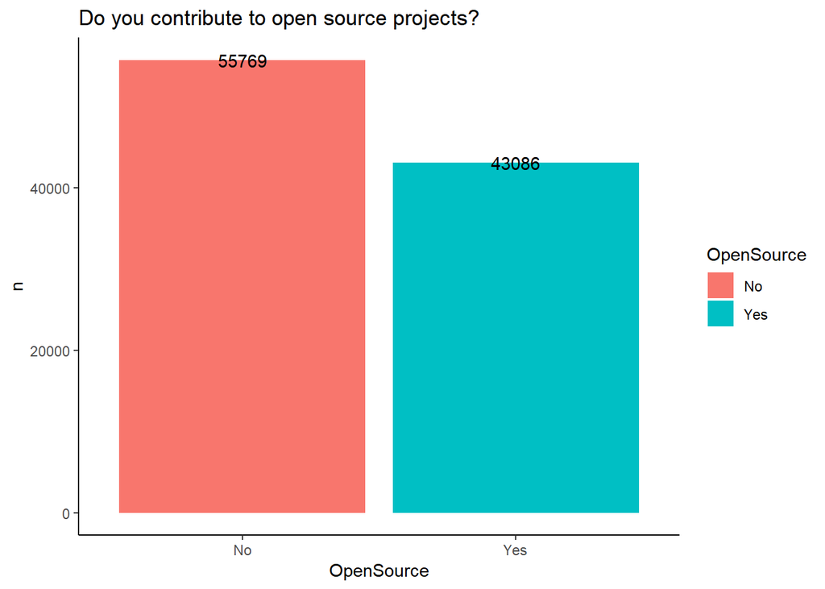

```r
questionOne <-ggplot(Q1, aes(OpenSource, n, group = OpenSource)) +
          geom_col(aes(fill=OpenSource), position = "dodge" ) +
            geom_text(aes(label = n), position = position_dodge(0.9)) +
  ggtitle("Do you contribute to open source projects?") +
  theme_classic()


questionOne
```

> Interpretacion of the graph

> > The graph shows that the people who don’t contribute to open source projects’ slightly more that people that actually contribute.

## Question 2

> In which country do you currently reside?

```r
country <- survey %>% count(Country) %>%
                            arrange(desc(n)) %>%
                            head(10)
country
```

```
## # A tibble: 10 x 2
##    Country                n
##    <fct>              <int>
##  1 United States      20309
##  2 India              13721
##  3 Germany             6459
##  4 United Kingdom      6221
##  5 Canada              3393
##  6 Russian Federation  2869
##  7 France              2572
##  8 Brazil              2505
##  9 Poland              2122
## 10 Australia           2018
```

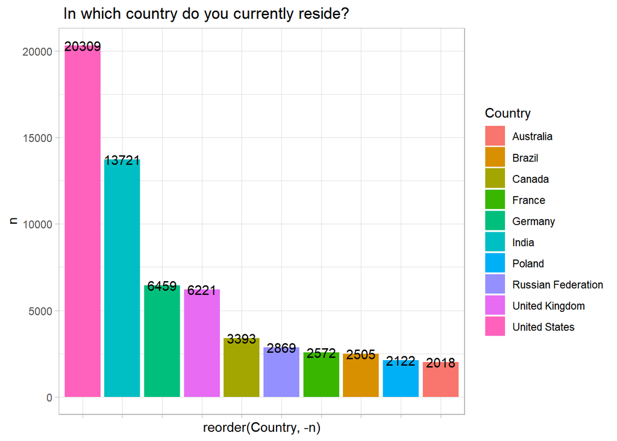

```r
 questionTwo <- ggplot(country,
                aes(x = reorder(Country, -n), y = n, fill = Country)) +
               geom_col() + ggtitle(" In which country do you currently reside?")+
    geom_text(aes(label = n), position = position_dodge(0.9)) +
                theme_light() +
                theme(axis.text.x = element_blank())
    questionTwo
```

> Interpretacion of the graph

> > Most of the people surveyed reside in the United States and India.

## Question 3

> Are you currently enrolled in a formal, degree-granting college or university program?"

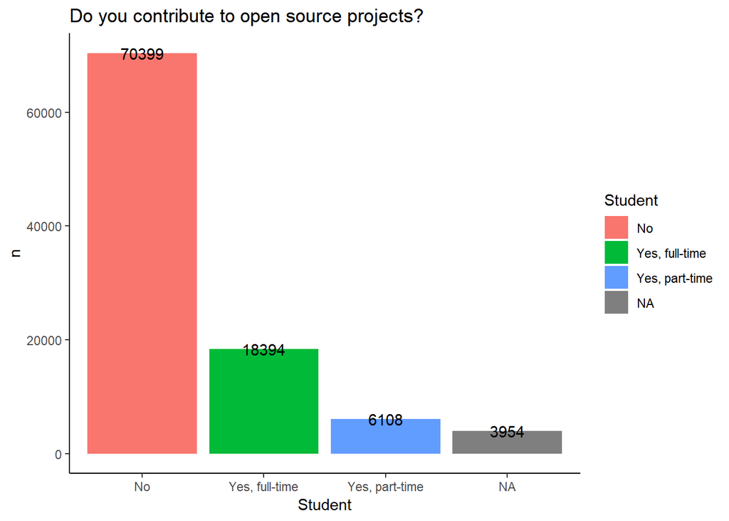

```r
     Q3 <- survey %>% count(Student)

      ggplot(Q3, aes(Student, n, group = Student)) +
          geom_col(aes(fill=Student), position = "dodge" ) +
            geom_text(aes(label = n), position = position_dodge(0.9)) +
  ggtitle("Do you contribute to open source projects?") +
  theme_classic()
```

> Interpretacion of the graph

> > The graph shows that most of the people who answered the survey are not students, therefore, they have a job.

## Question 4

> Which of the following best describes your current employmentstatus?

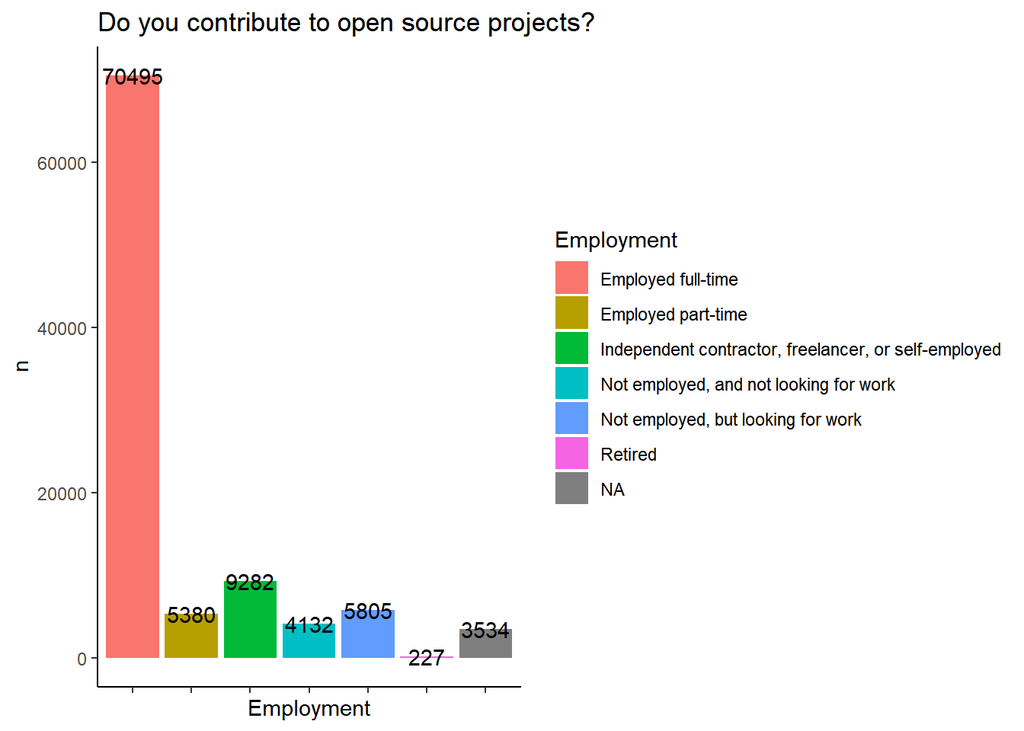

```r
      Q4 <- survey %>% count(Employment)




  ggplot(Q4, aes(Employment, n, group = Employment)) +
          geom_col(aes(fill=Employment), position = "dodge" ) +
            geom_text(aes(label = n), position = position_dodge(0.9)) +
  ggtitle("Do you contribute to open source projects?") +
  theme_classic() +
    theme(axis.text.x = element_blank())
```

> Interpretacion of the graph

> > The graph shows that more than 70% of people have a full-time job.

## Question 5

> Which of the following best describes the highest level of formal education that you’ve completed?

```r
       survey %>% count(FormalEducation)
```

```
## # A tibble: 10 x 2
##    FormalEducation                                                       n
##    <fct>                                                             <int>
##  1 Associate degree                                                   2970
##  2 Bachelorâs degree (BA, BS, B.Eng., etc.)                        43659
##  3 I never completed any formal education                              700
##  4 Masterâs degree (MA, MS, M.Eng., MBA, etc.)                     21396
##  5 Other doctoral degree (Ph.D, Ed.D., etc.)                          2214
##  6 Primary/elementary school                                          1656
##  7 Professional degree (JD, MD, etc.)                                 1447
##  8 Secondary school (e.g. American high school, German Realschule o~  8951
##  9 Some college/university study without earning a degree            11710
## 10 <NA>                                                               4152
```

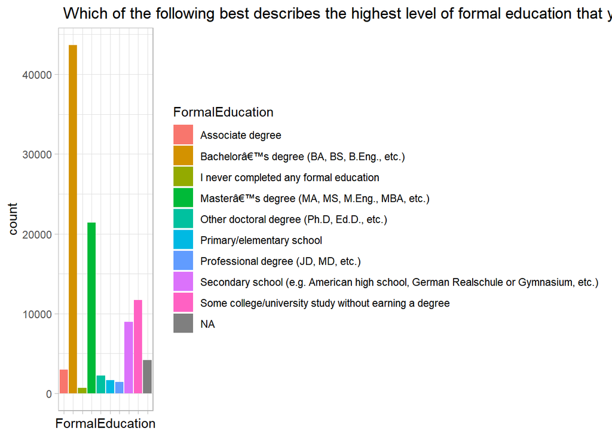

```r
      ggplot(survey, aes(FormalEducation, fill = FormalEducation)) +
          geom_bar()  +
          ggtitle(" Which of the following best describes the highest level of formal education that you've completed?") +
          theme_light() +
          theme(axis.text.x = element_blank())
```